# Report 1: Explore, Transform, Clean

Logan Hardy

3/04/2022

# Introduction

This report is based on data of lost, found, and adoptable pets in King county, Washington. Included is part of the path I took to clean, transform, and explore the data to discover intriguing findings and provide relevant recommendations.

# Data

The data I will be using comes from King county, WA which is broken down into four datasets:

1. King_County_pet_licenses
   - Number of pet licenses issued (ex. 138)
   - Year they were issued (ex. 2020)
   - Type of pet license (ex. Service Animal)
2. King_County_licenses_redeemed
   - Number of spays/neuters (ex. 17)
   - Year they occured (ex. 2020)
   - Type of license (ex. Issued or Redeemed)
3. King_County_stats
   - Year (ex. 2016)
   - Statistic description (ex. Number of animals adopted)
   - Statistics for that description and year (ex. 513)
4. King_CountyWA_animal_shelter
   - Animal information (ex. Animal_ID, age, breed, description)
   - Date lost, found, or adoptable (ex. 2021-12-28 12:00:00)
   - Impound number and current location (ex. K21-142594, In RASKC Home)

# Cleaning

I cleaned the data by pivoting, or changing the shape of some of the datasets from wide to long format to better analyze it. I also eliminated columns/rows that were all NAs (data that’s not available) and expanded the Memo (unstructured data) by creating 14 new columns that describe words/feelings found in the cell as well as the overall positivity weight of the text. This was done to extract more information from that column that we can use.

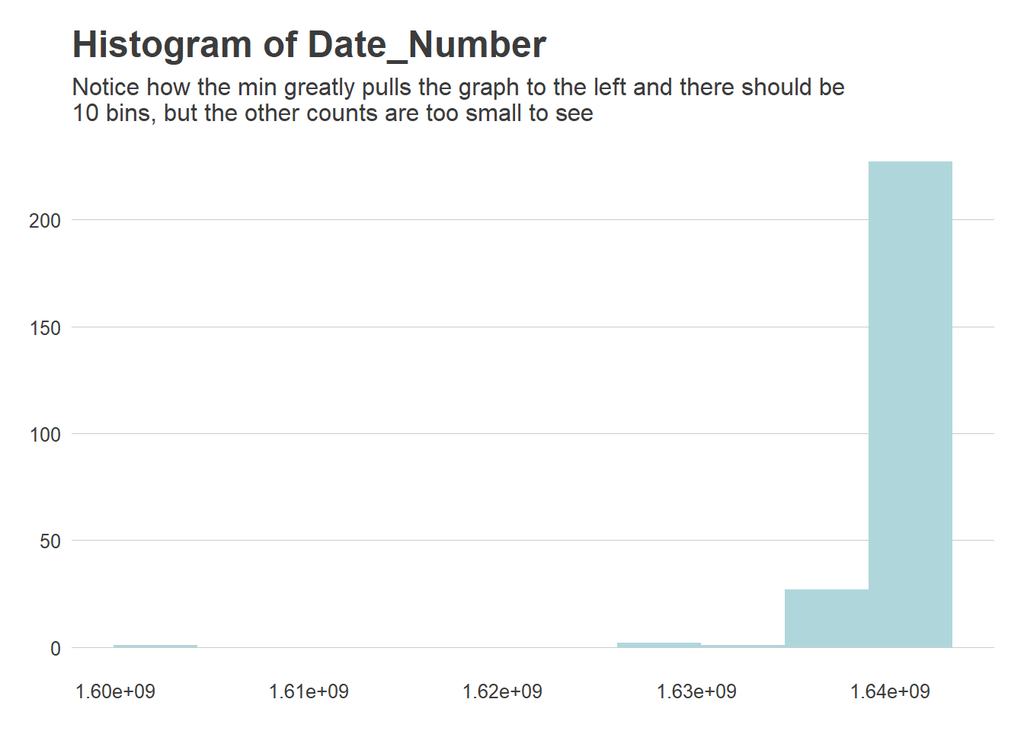

# Findings

The first visualization shows how the majority of animals are not spayed/neutered yet the next graph shows that the largest group of licenses are for spayed/neutered animals. This is interesting because it might imply that animals that have been spayed/neutered are less likely to be lost, found, or adoptable which may be because they are already in good homes.

The third visualization shows the number of issued vs redeemed spay/neuter vouchers, where in an ideal world, these would be the same. Further research should be done to discover why people aren’t redeeming these vouchers they have been issued.

Also included is a word graph which shows the number of times a word appears in the Memo with larger words appearing more often. Interesting how many mention pets near 12thand 64th streets, which could be high pet population areas or something that attracts them there like a dog park.

The last visualization shows the ratio of animals euthanized by owners request over time, and as can be seen, it has been increasing. This is alarming because this does not include animals euthanized because of vicious temperament, extreme illness, or bad behaviors.

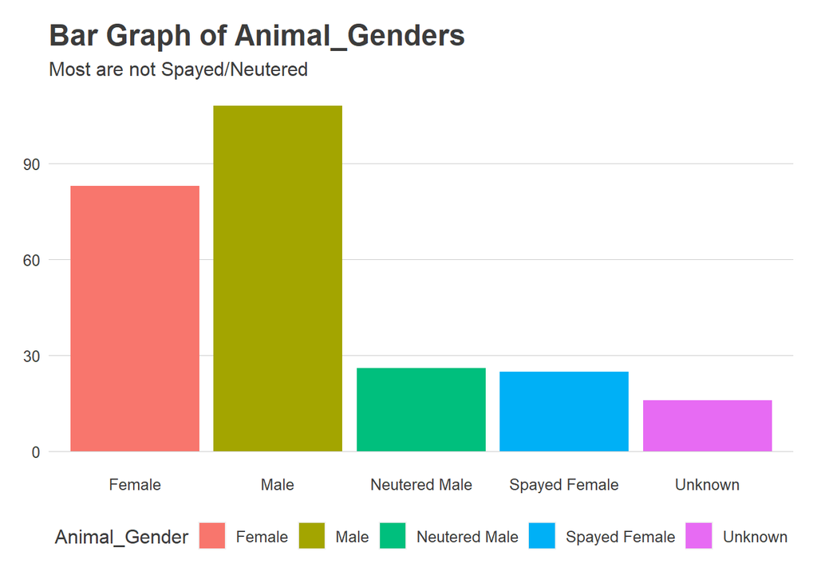

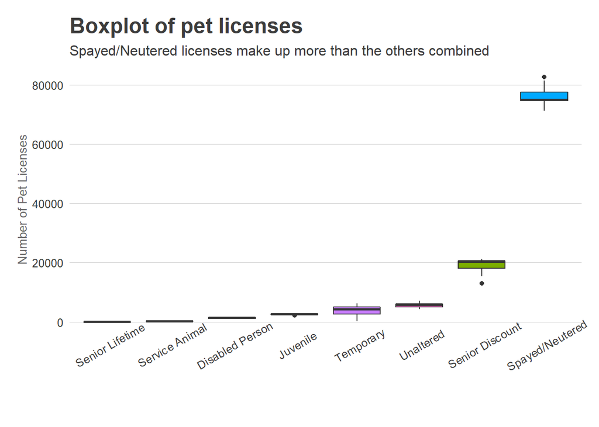

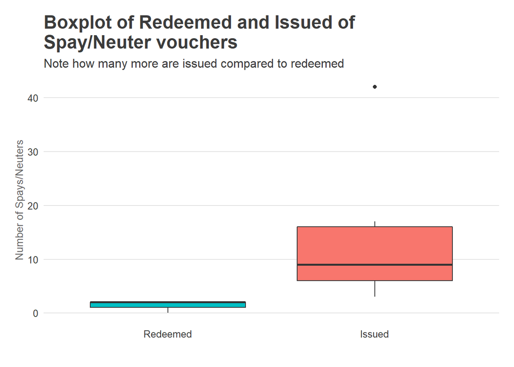

### Word Cloud: Words in Memo (Larger words are more frequent)

#### Notice the common streets animals are lost or found on

[interactive chart not shown]

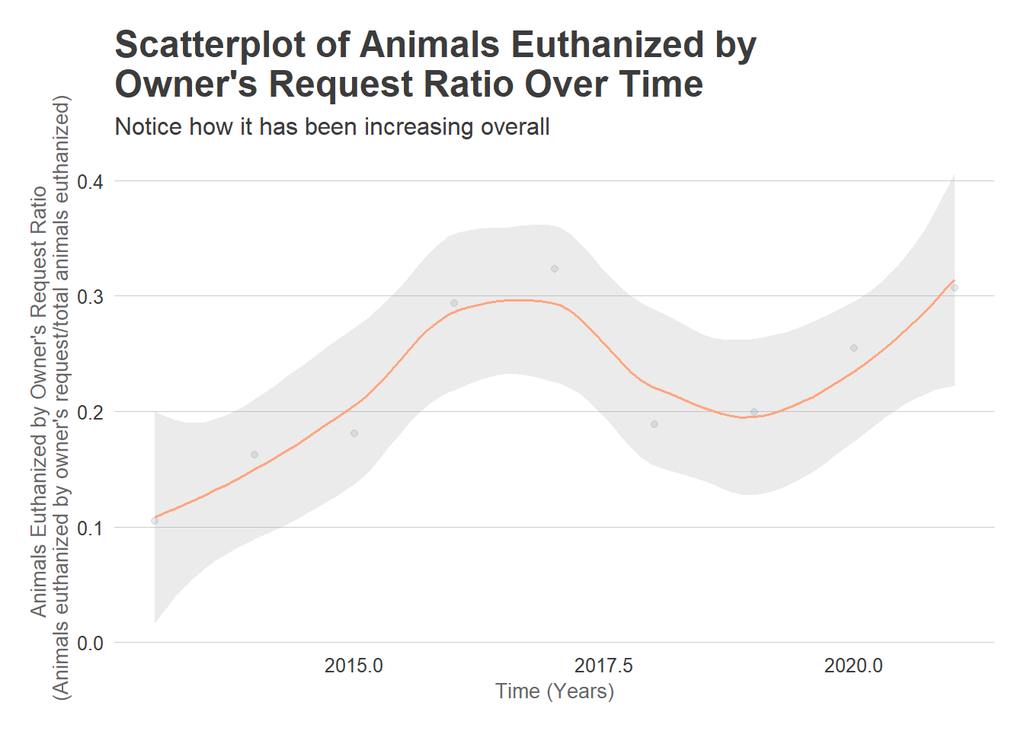

Year and number of vouchers that were less than 3

```
## [1] "In 2021 we only Redeemed 1 spay or neuter vouchers"
## [1] "In 2020 we only Redeemed 1 spay or neuter vouchers"
## [1] "In 2019 we only Redeemed 2 spay or neuter vouchers"
## [1] "In 2018 we only Redeemed 0 spay or neuter vouchers"
## [1] "In 2017 we only Redeemed 1 spay or neuter vouchers"
## [1] "In 2016 we only Redeemed 2 spay or neuter vouchers"
## [1] "In 2015 we only Redeemed 2 spay or neuter vouchers"
## [1] "In 2014 we only Redeemed 2 spay or neuter vouchers"
## [1] "In 2013 we only Redeemed 2 spay or neuter vouchers"
```

# Recommendations

Below are some recommendations for this nonprofit organization:

1. Follow up with individuals who are issued spay/neuter licenses to increase the number redeemed.
2. Help protect against animals getting loose by adding fences to parks (possibly on 12th and 64th streets).
3. Ensure pet owners are well educated regarding euthanization and other options.

# Limits and Conclusion

While I am confident in the findings based on this data from King County, there are some limitations as well as concerns that I have regarding the validity of my analysis. For one, many people may not be aware of this service and their pet data is not included, thus we cannot make proper hypotheses regarding population as a whole, but rather just those who use this site. The word map analysis should also be considered cautiously as there may be more of a link between memos that’s more difficult to connect with different wording. In conclusion, most of the animals that are lost, found, or adoptable are not spayed/neutered yet spayed/neutered pets are the majority of licenses issued. Thus, non-spayed/neutered animals might be more likely to be lost, found , or adoptable.

–End–

How hard was this assignment? Was it: too hard, too easy, or just right?

ANSWER: Just Right

Approximately how long did this assignment take you?

ANSWER: 20 hours